# R Notebook

```r
library(tidyr)
library(dplyr)
library(ggplot2)
library(scales)
library(ggthemes)
library(magrittr)
library(GGally)
```

```r
str(emailDF)
```

```
'data.frame':   9348 obs. of  30 variables:
 $ isSpam       : logi  FALSE FALSE FALSE FALSE FALSE FALSE ...
 $ isRe         : logi  TRUE FALSE FALSE FALSE TRUE TRUE ...
 $ numLines     : int  50 26 38 32 31 25 38 39 126 50 ...
 $ bodyCharCt   : int  1554 873 1713 1095 1021 718 1288 1182 5989 1554 ...
 $ underscore   : logi  FALSE FALSE FALSE FALSE FALSE FALSE ...
 $ subExcCt     : int  0 0 0 0 0 0 0 0 0 0 ...
 $ subQuesCt    : int  0 0 0 0 0 0 0 0 0 0 ...
 $ numAtt       : num  0 0 0 0 0 0 0 0 0 0 ...
 $ priority     : logi  FALSE FALSE FALSE FALSE FALSE FALSE ...
 $ numRec       : int  2 1 1 0 1 1 1 1 1 2 ...
 $ perCaps      : num  4.45 7.49 7.44 5.09 6.12 ...
 $ isInReplyTo  : logi  TRUE FALSE FALSE FALSE FALSE TRUE ...
 $ sortedRec    : logi  TRUE TRUE TRUE TRUE TRUE TRUE ...
 $ subPunc      : logi  FALSE FALSE FALSE FALSE FALSE FALSE ...
```

[output cut: 16 more lines]

# This assumes emailDFrp is built and ready to go…

```r
summary(emailDF)
```

```
   isSpam           isRe            numLines         bodyCharCt     underscore         subExcCt         subQuesCt           numAtt          priority
 Mode :logical   Mode :logical   Min.   :   2.00   Min.   :     6   Mode :logical   Min.   : 0.0000   Min.   : 0.0000   Min.   : 0.00000   Mode :logical
 FALSE:6951      FALSE:6343      1st Qu.:  19.00   1st Qu.:   587   FALSE:9222      1st Qu.: 0.0000   1st Qu.: 0.0000   1st Qu.: 0.00000   FALSE:9294
 TRUE :2397      TRUE :3005      Median :  32.00   Median :  1088   TRUE :126       Median : 0.0000   Median : 0.0000   Median : 0.00000   TRUE :54
                                 Mean   :  66.91   Mean   :  2844                   Mean   : 0.1313   Mean   : 0.1378   Mean   : 0.06579
                                 3rd Qu.:  59.00   3rd Qu.:  2192                   3rd Qu.: 0.0000   3rd Qu.: 0.0000   3rd Qu.: 0.00000
                                 Max.   :6319.00   Max.   :188505                   Max.   :42.0000   Max.   :12.0000   Max.   :18.00000
                                                                                    NA's   :20        NA's   :20
     numRec           perCaps        isInReplyTo     sortedRec        subPunc             hour       multipartText   hasImages       isPGPsigned
 Min.   :  0.000   Min.   :  0.000   Mode :logical   Mode :logical   Mode :logical   Min.   : 0.00   Mode :logical   Mode :logical   Mode :logical
 1st Qu.:  1.000   1st Qu.:  4.255   FALSE:6556      FALSE:948       FALSE:9085      1st Qu.: 8.00   FALSE:9020      FALSE:9326      FALSE:9172
 Median :  1.000   Median :  6.055   TRUE :2792      TRUE :8400      TRUE :263       Median :13.00   TRUE :328       TRUE :22        TRUE :176
 Mean   :  1.929   Mean   :  8.850                                                   Mean   :12.21
 3rd Qu.:  1.000   3rd Qu.:  9.059                                                   3rd Qu.:18.00
 Max.   :311.000   Max.   :100.000                                                   Max.   :23.00
 NA's   :282
    perHTML        subSpamWords      subBlanks       noHost          numEnd        isYelling          forwards     isOrigMsg         isDear
 Min.   :  0.000   Mode :logical   Min.   : 0.00   Mode :logical   Mode :logical   Mode :logical   Min.   : 0.00   Mode :logical   Mode :logical
 1st Qu.:  0.000   FALSE:8697      1st Qu.:10.53   FALSE:9318      FALSE:8209      FALSE:9134      1st Qu.: 0.00   FALSE:8988      FALSE:9270
 Median :  0.000   TRUE :644       Median :13.25   TRUE :29        TRUE :1139      TRUE :207       Median : 0.00   TRUE :360       TRUE :78
 Mean   :  6.517   NA's :7         Mean   :13.87   NA's :1                         NA's :7         Mean   :10.45
 3rd Qu.:  0.000                   3rd Qu.:15.69                                                   3rd Qu.:15.38
 Max.   :100.000                   Max.   :86.42                                                   Max.   :99.06
                                   NA's   :20
  isWrote          avgWordLen         numDlr
 Mode :logical   Min.   : 1.363   Min.   :   0.000
 FALSE:7442      1st Qu.: 4.208   1st Qu.:   0.000
 TRUE :1906      Median : 4.455   Median :   0.000
                 Mean   : 4.487   Mean   :   1.782
                 3rd Qu.: 4.729   3rd Qu.:   0.000
                 Max.   :26.000   Max.   :1977.000
```

303 incomplete rows in the dataset. This encompasses entries in: subSpamWords subQuesCt subExcCt subBlanks numRec noHost isYelling

```r
emailDF2 %>% group_by(isSpam) %>% summarise(Count=n()) %>% mutate(Pct = Count/sum(Count))%>%
  ggplot(aes(x=isSpam, y=Count, label=comma(Count))) + geom_bar(stat='identity') +  theme_light() + ggtitle("Spam vs. Non-Spam in Dataset") + scale_y_continuous("Count", labels =comma, limits=c(0,7500)) + scale_x_discrete("Is Spam - True or False")  + geom_text(vjust=-0.5)
```

[output not shown]

Our dataset is unbalanced: divided to 2,371 (26%) observations of Spam, and 6,674 (74%) observations of Non-Spam. This imbalancce in the dataset could introduce some higher false negative rates in some model types.

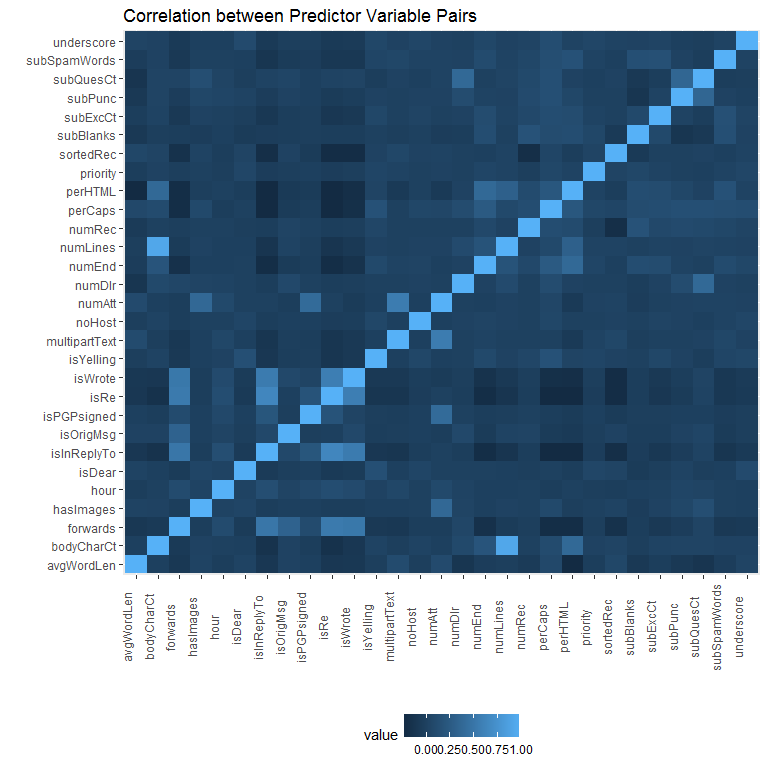

```r
#I'm going to excerpt complete cases only, to deal with the NA's
emailDF2<-emailDF[complete.cases(emailDF),]
AsVector<-emailDF2[,c(2:30)]
cormat<- (round(cor(AsVector),2))
cormat <- reshape::melt(cormat)
cormat %>% ggplot(aes(x=X1, y=X2, fill=value)) + geom_tile() + theme(legend.position = "bottom", axis.text.x = element_text(angle=90, vjust=-.5)) + scale_x_discrete("") + scale_y_discrete("") + ggtitle("Correlation between Predictor Variable Pairs")
```

The higher correlation between predictor variables could cause these variables to be collectively overweighted in modeling, as they may not be fully independent from one another.

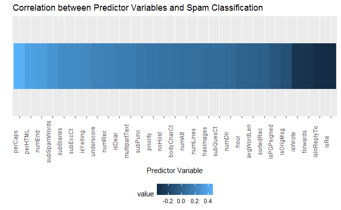

```r
cormat2<- (round(cor(emailDF2$isSpam, AsVector),2))
cormat2 <- reshape::melt(cormat2)
cormat2 %>% ggplot(aes(x=reorder(X2, -value), y=1, fill=value)) + geom_tile() + theme(legend.position = "bottom", axis.text.x = element_text(angle=90, vjust=-.5)) + scale_y_discrete("") + scale_x_discrete("Predictor Variable") + ggtitle("Correlation between Predictor Variables and Spam Classification")
```

At the individual level, the predictors that are mostly highly correlated with a Spam classification are (R>0.25): * perCaps * perHTML * numEnd * subSpamWords

Mild negative correlaton exists between the Spam classification and: * isRe * isinReplyTo * forwards * isWrote

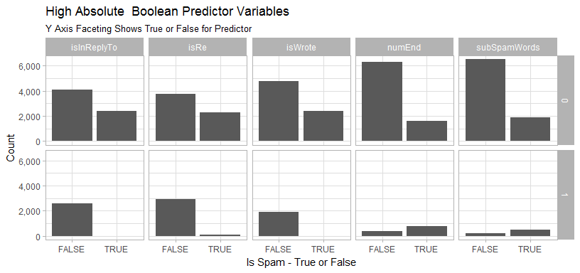

As described earlier, we know that the majority of observations in the overall dataset are classified False for the “IsSpam” indicator. For the three predictors that found a negative Correlation between the predictor and the “IsSpam” classification - isRe, isinReplyTo, and isWrote - nearly all “TRUE” occurrences of isSpam are “FALSE” for the predictor variable. For the Other two predictor variables - numEnd, and subSpamWords - there are some occurrences of Spam in both TRUE and FALSE cases for the predictor variable, but TRUE cases of the predictor variable have more cases of Spam than not Spam.

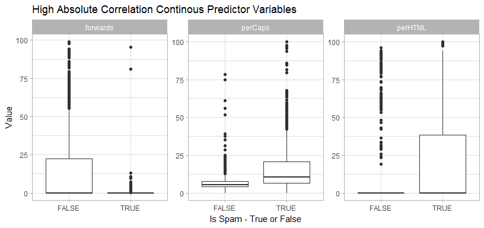

Examination of these predictor variables with high and low negative correlations give some perspective to how we should expect the models to split the data on the predictor variables, but we can also expect that some of the lower correlation variables might be involved in the decision of Spam versus Not Spam as well, perhaps providing some finer detailed distinctions between the two classes.